# calhoun-zachary-lab3

Zach Calhoun

1/18/2022

## 1 - Reproduce figure 1 from module 2

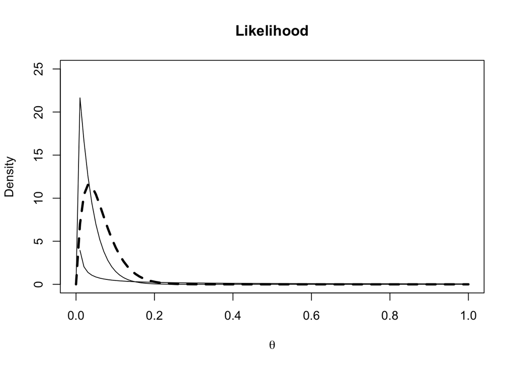

```r
set.seed(123)

th <- seq(0,1, length.out =100)
c <- seq(0,1, length.out = 100)

# Calculate the prior
a = 0.05
b = 1
sum_x = 1
n = 30
prior <- dbeta(th, a, b)
like <- dbeta(th, sum_x+1, n - sum_x + 1)
post <- dbeta(th, sum_x+a, n-sum_x+b)

# Graph this:

plot(th, like, type="l", main="Likelihood", ylab="Density", lty=2, lwd=3, xlab=expression(theta), ylim=c(0,25))
lines(th, prior)
lines(th, post)
```

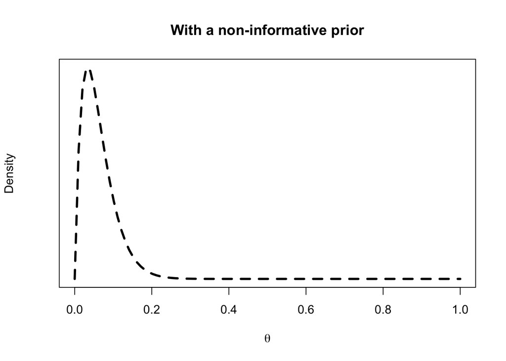

```r
plot(th,like, type="l", ylab="Density", lty=2, lwd=3,
     xlab=expression(theta), yaxt="n",
     main="With a non-informative prior")
```

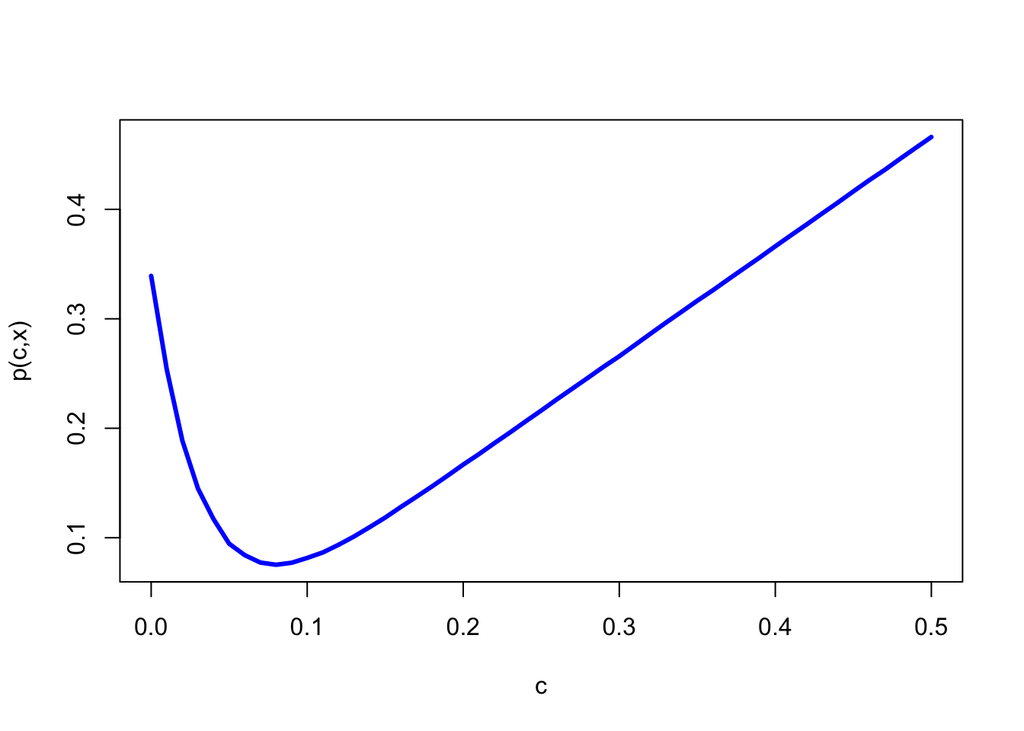

```r
# Calculate the loss
loss <- function(theta, c) {
  if(c < theta) {
    return(10*abs(theta-c))
  } else {
    return(abs(theta-c))
  }
}
an = a + sum_x
bn = b + n - sum_x
posterior_risk <- function(c, s = 30000) {

  theta <- rbeta(s, an, bn)

  loss <- apply(as.matrix(theta), 1, loss, c)

  risk <- mean(loss)
}

c <- seq(0, 0.5, by=0.01)
post_risk <- apply(as.matrix(c), 1, posterior_risk)

plot(c, post_risk, type="l",col="blue", lwd=3, ylab='p(c,x)')
```

```r
# Calculate the minimum
print(c[which.min(post_risk)])
```

```
## [1] 0.08
```

# 2 - Calculate the posterior risk

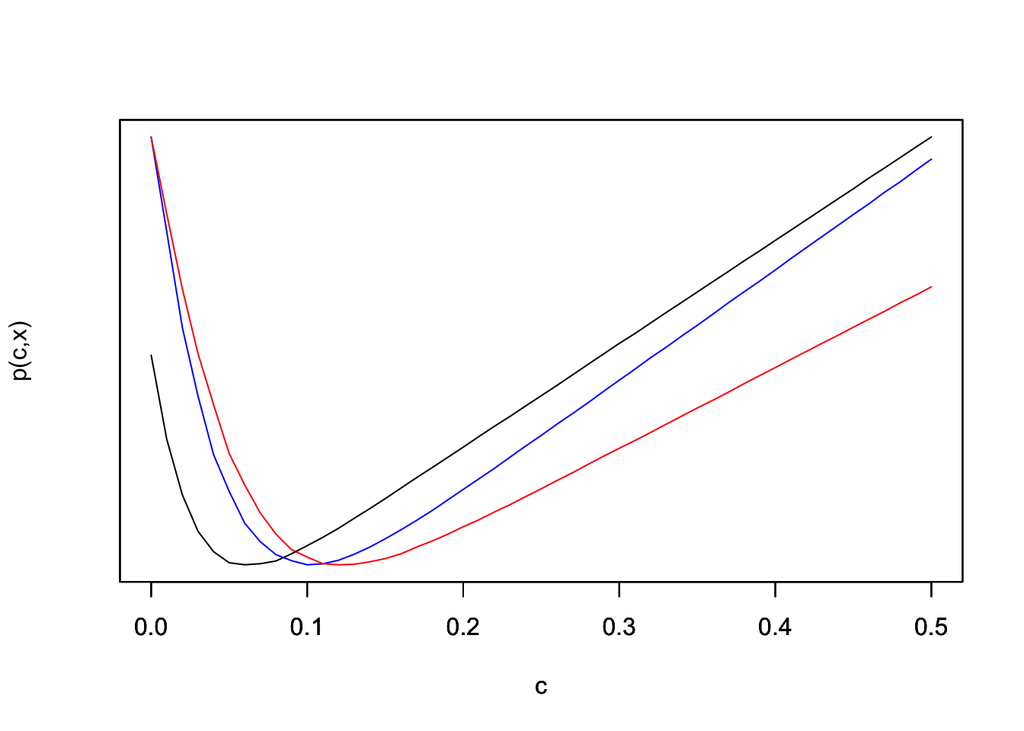

```r
posterior_risk <- function(c, a_prior, b_prior, sum_x, n, s=30000) {

  a_post = a_prior + sum_x
  b_post = b_prior + n - sum_x

  theta <- rbeta(s, a_post, b_post)

  loss <- apply(as.matrix(theta), 1, loss, c)

  risk <- mean(loss)
}
as <- c(0.5, 1, 0.05); bs <- c(1,1,10)
post_risk <- matrix(NA, 3, length(c))

for(i in 1:3) {
  a_prior = as[i]
  b_prior = bs[i]

  post_risk[i,] <- apply(as.matrix(c), 1, posterior_risk, a_prior, b_prior, sum_x, n)
}


plot(c, post_risk[1,], type="l", col="blue", lty=1, yaxt="n", ylab="p(c,x)")
par(new=T)
plot(c, post_risk[2,], type="l", col="red", lty=1, yaxt="n",ylab="")
par(new=T)
plot(c, post_risk[3,], type="l", col="black", lty=1, yaxt="n", ylab="")
```

# Task 3. Consider the Bayes procedure, $c = \bar{x}$, and c = 0.1.

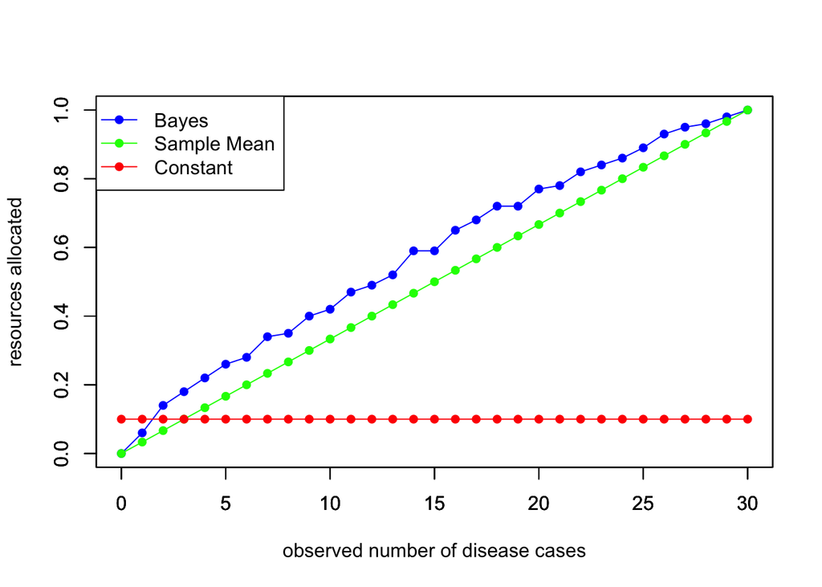

```r
sum_xs = seq(0,30)
n <- 30
a <- 0.05; b <-1

min_c = matrix(NA, 3, length(sum_xs))

optimal_c <- function(sum_x, a_prior, b_prior, n, s=500) {

  # Set up values of C to consider.
  c <- seq(0,1, by=0.01)
  # Calculate posterior risk for each c
  post_risk <- apply(as.matrix(c), 1, posterior_risk, a_prior,b_prior, sum_x, n, s)
  # Return the optimal C
  c[which.min(post_risk)]
}

# Return the bayesian risk
min_c[1,] = apply(as.matrix(sum_xs), 1, optimal_c, a, b, n)

min_c[2,] = sum_xs/n
min_c[3,] = 0.1

plot(sum_xs, min_c[1,], col='blue',type='o', pch=16,
     ylab="resources allocated", xlab="observed number of disease cases",
     ylim=c(0,1))
par(new=T)
plot(sum_xs, min_c[2,], type='o', col='green',
     pch=16, ylab='',xlab='', ylim=c(0,1))
par(new=T)
plot(sum_xs, min_c[3,], type='o',col='red',
     pch=16, ylab='',xlab='', ylim=c(0,1))
legend("topleft", lty=c(1,1,1), pch=c(16,16,16),
       col=c("blue","green", "red"),
       legend=c("Bayes", "Sample Mean", "Constant"))
```

# Task 4 - Plot the frequentist risk as a function of $\theta$.

Frequentist risk is defined as:
$$R(\theta, \delta) = \mathbb{E}(\ell(\theta, \delta(X))|\mathbf{\theta} =\theta)$$
Therefore, we must calculate the loss as a function of $\theta$.

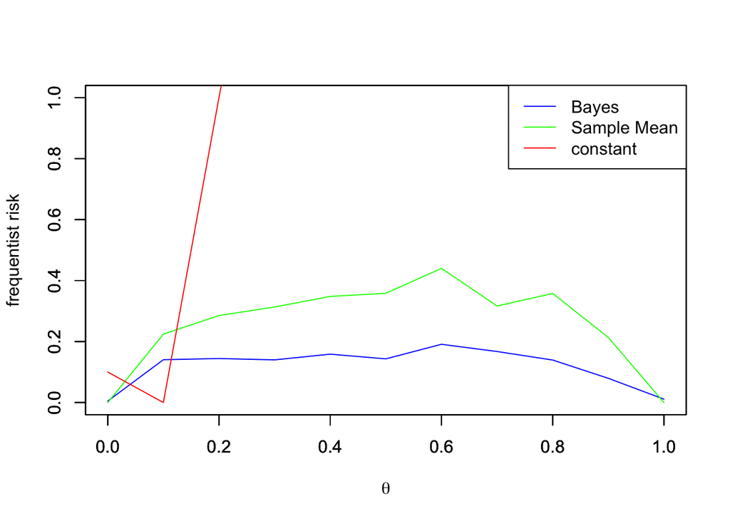

```r
th <- seq(0,1, by=0.1)


frequentist_risk <- function(theta) {
  sum_xs = rbinom(100, 30, theta)

  bayes_optimal <- apply(as.matrix(sum_xs), 1, optimal_c, a, b, n, s=100)

  mean_c <- sum_xs/30

  risk = matrix(NA, 3, length(sum_xs))

  # Calculate bayes risk
  loss1 <- apply(as.matrix(bayes_optimal), 1, loss, theta=theta)
  loss2 <- apply(as.matrix(mean_c), 1, loss, theta=theta)

  r1 <- mean(loss1)
  r2 <- mean(loss2)
  r3 <- loss(theta,0.1)
  return(c(r1, r2, r3))
}

risk <- apply(as.matrix(th), 1, frequentist_risk)

plot(th, risk[1,], col='blue', type='l', ylab='frequentist risk', xlab=expression(theta), ylim=c(0,1))

par(new=T)

plot(th, risk[2,], col='green', type='l', ylab='',xlab='', ylim=c(0,1))
par(new=T)
plot(th, risk[3,], col='red', type='l', ylab='',xlab='', ylim=c(0,1))
legend("topright", lty=c(1,1,1), col=c("blue","green", "red"), legend=c("Bayes", "Sample Mean", "constant"))
```

In general, the Bayes estimator tends to yield the lowest frequentist risk.

# Task 5

Because there are thetas for which each of the estimators has the lowest risk, all of the estimators are considered admissible. The sample mean estimator appears to be the best estimator when theta is either really close to 0 or really close to 1, and the constant is optimal when theta is close to 0.1. However, in general, the Bayes estimator has the lowest frequentist risk.

2. (15 points total) *The Uniform-Pareto*
   **The goal of this problem is to continue getting more practice calculating the posterior distribution.**
   Suppose $a < x < b.$ Consider the notation $I_{(a,b)}(x),$ where $I$ denotes the indicator function. We define $I_{(a,b)}(x)$ to be the following:
   $$I_{(a,b)}(x)=
   \begin{cases}
   1 & \text{if $a < x < b$,}
   \\
   0 &\text{otherwise.}
   \end{cases}$$

Let
$$\begin{aligned}
\color{red}{X=x} \mid \theta &\sim \text{Uniform}(0,\theta)\\
\theta &\sim \text{Pareto}(\alpha,\beta),
\end{aligned}$$
where $p(\theta) = \dfrac{\alpha\beta^\alpha}{\theta^{\alpha+1}}I_{(\beta,\infty)}(\theta).$ Write out the likelihood $p(X=x\mid \theta).$ Then calculate the posterior distribution of $\theta|X=x.$

The likelihood is given by:

$$p(X=x|\theta) = \frac{1}{\theta}I_{(a,b)}(x)$$

3. (15 points total) *The Bayes estimator or Bayes rule*  
   **The goal of this problem is to practice a similar problem that we considered in Module 2, where we derived the Bayes rule under squared error loss and found the result was the posterior mean.**
1. (5 pts) Find the Bayes estimator (or Bayes rule) when the loss function is $L(\theta, \delta(x))~=~c~(\theta-\delta(x))^2,$ where $\textcolor{red}{c >0}$ is a constant.
2. (10 pts) Derive the Bayes estimator (or Bayes rule) when $L(\theta, \delta(x)) = w(\theta) (g(\theta)-\delta(x))^2.$ Do so without writing any integrals. Note that you can write $\rho(\pi,\delta(x)) = E[L(\theta,\delta(x))|X].$